# UNICEF Report

Author

Reema Hamad

## *Data reference*

```python
import pandas as pd
from plotnine import *

df = pd.read_csv("cleaned_unicef_indicator_1.csv")
```

## Top 10 years for Afghanistan

This displays the 10 years in Afghanistan with the highest values shownnn on the indicator value. it is a visual summary of when progress has been made and can aid in identifying opportunities.

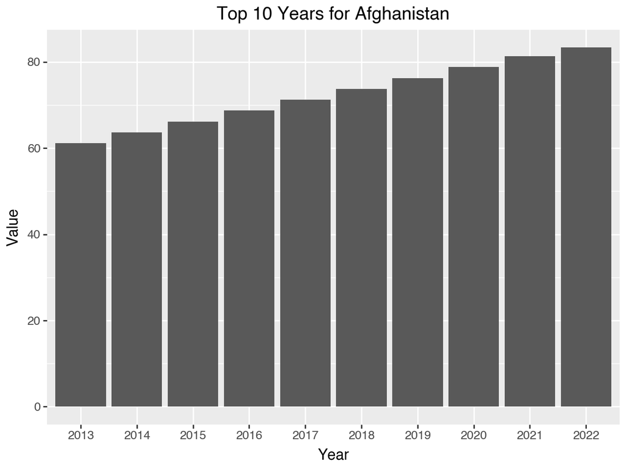

```python
afg = df[df["country"] == "Afghanistan"]
top_years = afg.sort_values("obs_value", ascending=False).head(10)

(
    ggplot(top_years, aes(x="factor(time_period)", y="obs_value"))
    + geom_col()
    + labs(title="Top 10 Years for Afghanistan", x="Year", y="Value")
)
```

## Scatter Plot Year vs Value with Regression Line

Each point represents a year, with the regression line showcaseing the direction of change over time. an ascending line means improvement, yet a downward slope would mean a decrease in growth.

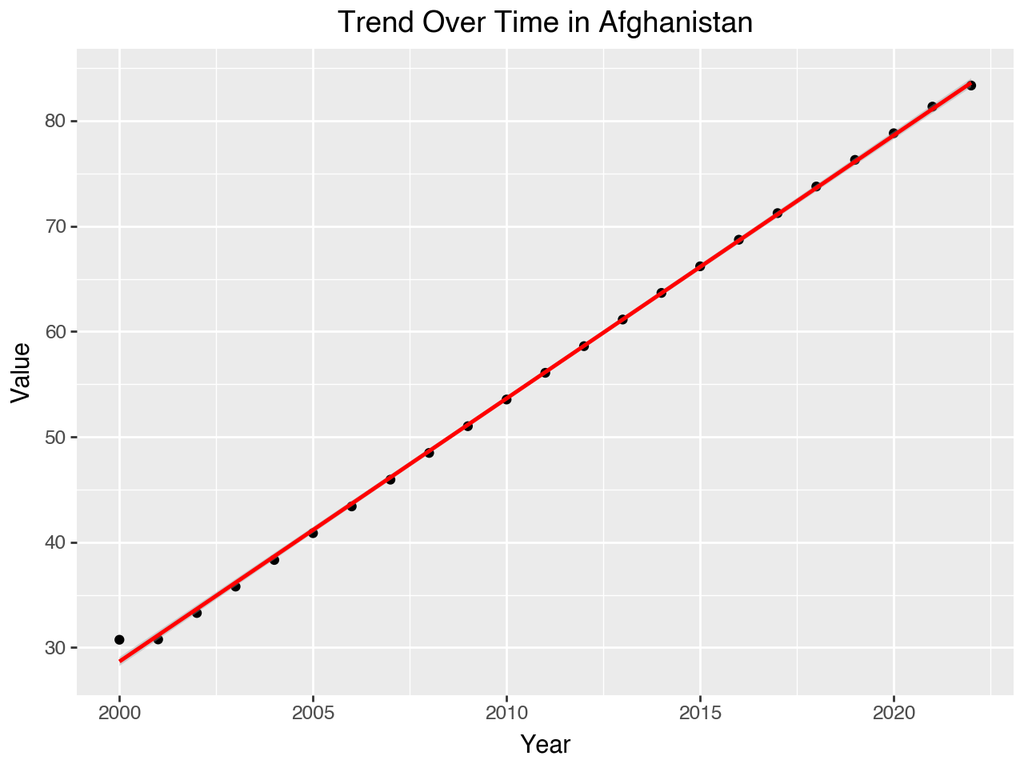

```python
(
    ggplot(afg, aes(x="time_period", y="obs_value"))
    + geom_point()
    + geom_smooth(method="lm", color="red")
    + labs(title="Trend Over Time in Afghanistan", x="Year", y="Value")
)
```